# compare new and old metadata

```r
# load libraries
library(here)
library(data.table)
library(stringr)
library(dplyr)
library(tidyr)
library(ggplot2)
library(readxl)
library(ggpubr)
source(here::here("src/parse_sample_id.R"))
```

```r
complete_meta_dt <- read_excel(
  here::here("metadata/complete/brain_virome_metadata.v3.xlsx")
) |>
  mutate(
    sample_ID = case_when(
      Pool == "p1733" ~ Alt_ID2,
      Pool == "p1849" ~ Alt_ID2,
      Pool == "p1894" ~ gsub("_B", "_1B", Alt_ID2),
      TRUE ~ Barcode
      ),
    tissue = `Brain Region\r\n`
    )
```

```r
colnames(complete_meta_dt)
```

```
 [1] "Biobank"                                   "Pool"
 [3] "Barcode"                                   "Alt_ID1"
 [5] "Alt_ID2"                                   "patient_ID"
 [7] "Gender"                                    "Age"
 [9] "B&B Scale"                                 "Diagnosis"
[11] "PathDx"                                    "LBD"
[13] "Thal"                                      "TDP-43"
[15] "ClinicalDx"                                "Family History"
[17] "Disease Duration (years)"                  "Tissue Type (FF, FFPE)"
[19] "Amount of sample used (mg)"                "Nucleic Acid type\r\n"
[21] "Species latin name\r\n"                    "Brain Region\r\n"
[23] "Total DNA (ng/ul)"                         "Total DNA A260/A280"
[25] "Host depleted Microbial DNA (ng/ul)"       "Host depleted Microbial DNA A260/A280"
[27] "Total RNA (ng/ul)"                         "Total RNA A260/A280"
[29] "Volume used for library prep/capture (ul)" "Shipment number"
[31] "NIA-AA ABC Score"                          "Other Neurodegenerative Pathology"
[33] "sample_ID"                                 "tissue"
```

```r
complete_meta_dt |>
  distinct(tissue)
```

| tissue |
| --- |
| Occipital |
| Hippocampus |
| Frontal |
| Inferior Cortex |
| NA |

```r
complete_meta_dt |>
  filter(is.na(tissue))
```

| Biobank | Pool | Barcode | Alt_ID1 | Alt_ID2 | patient_ID | Gender | Age | B&B Scale | Diagnosis | PathDx | LBD | Thal | TDP-43 | ClinicalDx | Family History | Disease Duration (years) | Tissue Type (FF, FFPE) | Amount of sample used (mg) | Nucleic Acid type | Species latin name | Brain Region | Total DNA (ng/ul) | Total DNA A260/A280 | Host depleted Microbial DNA (ng/ul) | Host depleted Microbial DNA A260/A280 | Total RNA (ng/ul) | Total RNA A260/A280 | Volume used for library prep/capture (ul) | Shipment number | … |
| --- | --- | --- | --- | --- | --- | --- | --- | --- | --- | --- | --- | --- | --- | --- | --- | --- | --- | --- | --- | --- | --- | --- | --- | --- | --- | --- | --- | --- | --- | --- |
| UCLA | x5 | 26-000780-54A1-UBD01-00-01-DB01-02-68 | A05-00092-DLBD | A05-00092-DLBD | A05-00092 | M | 68 | NA | DLBD | NA | NA | NA | NA | NA | NA | NA | FFPE | 25 | DNA | Homo sapiens | NA | NA | NA | NA | NA | NA | NA | 25 | 5 | … |
| UCLA | x5 | 26-000780-54A1-UBD01-00-02-DB01-02-69 | A05-00092-DLBD | A05-00092-DLBD | A05-00092 | M | 68 | NA | DLBD | NA | NA | NA | NA | NA | NA | NA | FFPE | 25 | DNA | Homo sapiens | NA | NA | NA | NA | NA | NA | NA | 25 | 5 | … |
| UCLA | x5 | 26-000781-54A1-UBD01-00-01-DB01-02-70 | A07-00089-Control | A07-00089-Control | A07-00089 | M | 13 | NA | Control | NA | NA | NA | NA | NA | NA | NA | FFPE | 25 | DNA | Homo sapiens | NA | NA | NA | NA | NA | NA | NA | 25 | 5 | … |
| UCLA | x5 | 26-000781-54A1-UBD01-00-02-DB01-02-71 | A07-00089-Control | A07-00089-Control | A07-00089 | M | 13 | NA | Control | NA | NA | NA | NA | NA | NA | NA | FFPE | 25 | DNA | Homo sapiens | NA | NA | NA | NA | NA | NA | NA | 25 | 5 | … |
| UCLA | x5 | 26-000782-54A1-UBD01-00-01-DB01-02-72 | A12-00103-DLBD | A12-00103-DLBD | A12-00103 | M | 78 | NA | DLBD | NA | NA | NA | NA | NA | NA | NA | FFPE | 25 | DNA | Homo sapiens | NA | NA | NA | NA | NA | NA | NA | 25 | 5 | … |
| UCLA | x5 | 26-000782-54A1-UBD01-00-02-DB01-02-73 | A12-00103-DLBD | A12-00103-DLBD | A12-00103 | M | 78 | NA | DLBD | NA | NA | NA | NA | NA | NA | NA | FFPE | 25 | DNA | Homo sapiens | NA | NA | NA | NA | NA | NA | NA | 25 | 5 | … |
| UCLA | x5 | 26-000783-54A1-UBD01-00-01-DB01-02-74 | AAW17-00095-Control | AAW17-00095-Control | AAW17-00095 | F | 26 | NA | Control | NA | NA | NA | NA | NA | NA | NA | FFPE | 25 | DNA | Homo sapiens | NA | NA | NA | NA | NA | NA | NA | 25 | 5 | … |
| UCLA | x5 | 26-000784-54A1-UBD01-00-01-DB01-02-75 | A10-00037-Control | A10-00037-Control | A10-00037 | F | 42 | NA | Control | NA | NA | NA | NA | NA | NA | NA | FFPE | 25 | DNA | Homo sapiens | NA | NA | NA | NA | NA | NA | NA | 25 | 5 | … |
| UCLA | x5 | 26-000784-54A1-UBD01-00-02-DB01-02-76 | A10-00037-Control | A10-00037-Control | A10-00037 | F | 42 | NA | Control | NA | NA | NA | NA | NA | NA | NA | FFPE | 25 | DNA | Homo sapiens | NA | NA | NA | NA | NA | NA | NA | 25 | 5 | … |
| UCLA | x5 | 26-000785-54A1-UBD01-00-01-DB01-02-77 | A16-00042-DLBD | A16-00042-DLBD | A16-00042 | F | 70 | NA | DLBD | NA | NA | NA | NA | NA | NA | NA | FFPE | 25 | DNA | Homo sapiens | NA | NA | NA | NA | NA | NA | NA | 25 | 5 | … |

[output cut: 6 more lines]

```r
complete_meta_dt |>
  filter(Pool != "x5") |>
  distinct(patient_ID, Age, Diagnosis) |>
  arrange(patient_ID)
```

| patient_ID | Age | Diagnosis |
| --- | --- | --- |
| 00-120 | 76 | AD |
| 00-171 | 79 | AD |
| 00-180 | 78 | AD |
| 00-198 | 69 | AD |
| 00-209 | 76 | AD |
| 01-006 | 72 | AD |
| 01-169 | 75 | AD |
| 02-020 | 74 | AD |
| 02-187 | 64 | AD |
| 02-203 | 81 | AD |

[output cut: 90 more lines]

# Donor Age at Death ~ AD

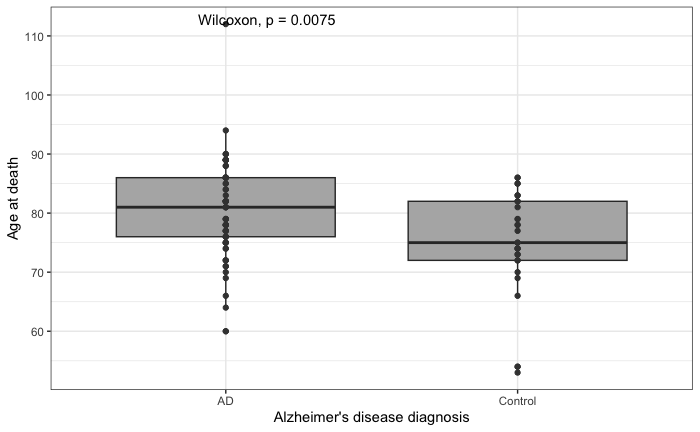

```r
age_p <- complete_meta_dt |>
  filter(Pool != "x5") |>
  distinct(patient_ID, Age, Diagnosis) |>
  ggplot(aes(x = Diagnosis, y = Age)) +
  geom_boxplot(outlier.shape = NA, fill = "grey70") +
  geom_point(color = "grey25") +
  stat_compare_means(method = "wilcox.test") +
  theme_bw() +
  labs(
    x = "Alzheimer's disease diagnosis",
    y = "Age at death"
  )

age_p
```

```r
ggsave(
  here::here("charts/AD_status_age_at_death.pdf"),
  age_p,
  width = 5,
  height = 4
)
```

load tax tables

```r
tax_file_list <- c(
  here::here("data/tax_profiles/esviritu_p2058.tax_profile.tsv"),
  here::here("data/tax_profiles/esviritu_p1733.tax_profile.tsv"),
  here::here("data/tax_profiles/esviritu_p1849.tax_profile.tsv"),
  here::here("data/tax_profiles/esviritu_p1894.tax_profile.tsv")
)


esv_tax_dt <- rbindlist(lapply(tax_file_list, fread))

esv_tax_dt <- esv_tax_dt |>
  filter(
    read_count >= 10,
    !genus %in% c(
      "g__Betacoronavirus", "g__Gammaretrovirus", "g__Respirovirus",
      "g__Lentivirus", "g__Alphacoronavirus", "g__Orthorubulavirus",
      "g__Enterovirus"
      ),
    !species %in% c(
      "s__Betapapillomavirus 1", "s__Betapapillomavirus 2",
      "s__Betapapillomavirus 3", "s__Human papillomavirus",
      "s__Triatovirus nigereginacellulae", "s__Lepidopteran ambidensovirus 1",
      "s__Scythevirus dianchis", "s__Blattambidensovirus incertum1",
      "s__Pigeon aviadenovirus B", "s__Alphainfluenzavirus influenzae"
      ),
    !grepl("s__unclassified", species)
    ) |>
  separate(sample_ID, c("sample_ID", "Pool"), sep = "[.]")
```

```r
esv_tax_dt |>
  distinct(species)
```

| species |
| --- |
| s__Alphatorquevirus homin13 |
| s__TTV-like mini virus |
| s__Torque teno virus |
| s__Gammapapillomavirus 8 |
| s__Dependoparvovirus primate1 |
| s__Erythroparvovirus primate1 |
| s__Lymphocryptovirus humangamma4 |
| s__Gammatorquevirus homidi14 |
| s__Roseolovirus humanbeta6b |
| s__Alphapolyomavirus quintihominis |

[output cut: 41 more lines]

```r
tax_fmt_dt <- esv_tax_dt |>
  mutate(
    sample_ID = gsub("-A$", "", sample_ID),
    sample_ID = case_when(
      sample_ID == "SEVAD_BF5" ~ "SEVAD_2BF5",
      sample_ID == "SEVAD_BH5" ~ "SEVAD_1BO5",
      sample_ID == "SEVAD_BO5" ~ "SEVAD_1BO5",
      TRUE ~ sample_ID
    )
    )
```

```r
anti_join(
  tax_fmt_dt,
  complete_meta_dt,
  by = c("sample_ID", "Pool")
) |>
  filter(
    !grepl("CMMR", sample_ID), # remove controls
    !grepl("-B$", sample_ID), # remove alternative conditions
    !grepl("-C$", sample_ID) # remove alternative conditions
    )
```

| sample_ID | Pool | filtered_reads_in_sample | kingdom | phylum | tclass | order | family | genus | species | subspecies | read_count | RPKMF | avg_read_identity | consensus_ref_identity | assembly_list |
| --- | --- | --- | --- | --- | --- | --- | --- | --- | --- | --- | --- | --- | --- | --- | --- |

```r
anti_join(
  complete_meta_dt,
  tax_fmt_dt,
  by = c("sample_ID", "Pool")
) |>
  filter(
    !grepl("CMMR", sample_ID), # remove controls
    Pool != "x5" # remove nonexistent pool
    )
```

| Biobank | Pool | Barcode | Alt_ID1 | Alt_ID2 | patient_ID | Gender | Age | B&B Scale | Diagnosis | PathDx | LBD | Thal | TDP-43 | ClinicalDx | Family History | Disease Duration (years) | Tissue Type (FF, FFPE) | Amount of sample used (mg) | Nucleic Acid type | Species latin name | Brain Region | Total DNA (ng/ul) | Total DNA A260/A280 | Host depleted Microbial DNA (ng/ul) | Host depleted Microbial DNA A260/A280 | Total RNA (ng/ul) | Total RNA A260/A280 | Volume used for library prep/capture (ul) | Shipment number | … |
| --- | --- | --- | --- | --- | --- | --- | --- | --- | --- | --- | --- | --- | --- | --- | --- | --- | --- | --- | --- | --- | --- | --- | --- | --- | --- | --- | --- | --- | --- | --- |
| UCLA | p1733 | 11-000054-54A1-OBD01-01-01-DB01-03-04 | 2011-13-O | HELTHY_B2 | 2011-13 | F | 66 | Not Applicable | Control | NA | NA | NA | NA | NA | NA | NA | FF | 150 | DNA | Homo sapiens | Occipital | 45.68 | 2.04 | 30.60 | 1.80 | 13.32 | 1.97 | 25 | 1 | … |
| UCLA | p1733 | 99-000060-54A1-OBD01-01-01-DB01-03-19 | 99-113-O | SEVAD_B10 | 99-113 | F | 82 | 5 | AD | NA | NA | NA | NA | NA | NA | NA | FF | 150 | DNA | Homo sapiens | Occipital | 46.20 | 1.93 | 33.28 | 1.83 | 27.44 | 2.04 | 25 | 1 | … |
| UCLA | p1894 | 11-000054-54A1-FBD01-01-02-DB01-03-21 | 2011-13-F | HELTHY_BF2 | 2011-13 | F | 66 | Not Applicable | Control | NA | NA | NA | NA | NA | NA | NA | FF | 150 | DNA | Homo sapiens | Frontal | 60.00 | 1.79 | NA | NA | NA | NA | 25 | 3 | … |
| UCLA | p1894 | 08-000057-54A1-FBD01-01-02-DB01-03-24 | 08-143-F | MODAD_BF1 | 08-143 | M | 82 | 3-4 | AD | NA | NA | NA | NA | NA | NA | NA | FF | 150 | DNA | Homo sapiens | Frontal | 59.70 | 1.80 | NA | NA | NA | NA | 25 | 3 | … |
| UCLA | p1894 | 02-000068-54A1-FBD01-01-01-DB01-03-34 | 02-020-F | SEVAD_BF8 | 02-020 | M | 74 | 6 | AD | NA | NA | NA | NA | NA | NA | NA | FF | 150 | DNA | Homo sapiens | Frontal | 49.20 | 1.85 | NA | NA | NA | NA | 25 | 3 | … |
| UCLA | p1894 | 99-000060-54A1-FBD01-01-02-DB01-03-36 | 99-113-F | SEVAD_BF10 | 99-113 | F | 82 | 5 | AD | NA | NA | NA | NA | NA | NA | NA | FF | 150 | DNA | Homo sapiens | Frontal | 49.90 | 1.86 | NA | NA | NA | NA | 25 | 3 | … |
| UCLA | p1894 | 08-000057-54A1-HBD01-01-01-DB01-03-37 | 08-143-H | MODAD_BH1 | 08-143 | M | 82 | 3-4 | AD | NA | NA | NA | NA | NA | NA | NA | FF | 150 | DNA | Homo sapiens | Hippocampus | 30.90 | 1.88 | NA | NA | NA | NA | 25 | 3 | … |
| UCLA | p1894 | 00-000061-54A1-HBD01-01-01-DB01-03-42 | 00-180-H | SEVAD_BH3 | 00-180 | M | 78 | 6 | AD | NA | NA | NA | NA | NA | NA | NA | FF | 150 | DNA | Homo sapiens | Hippocampus | 49.90 | 1.86 | NA | NA | NA | NA | 25 | 3 | … |
| UCLA | p1894 | 02-000068-54A1-HBD01-01-01-DB01-03-47 | 02-020-H | SEVAD_BH8 | 02-020 | M | 74 | 6 | AD | NA | NA | NA | NA | NA | NA | NA | FF | 150 | DNA | Homo sapiens | Hippocampus | 81.00 | 1.82 | NA | NA | NA | NA | 25 | 3 | … |
| UCLA | p1894 | 14-000018-54A1-OBD01-01-01-DB01-01-32 | 14-150-O | MODAD_2BO3 | 14-150 | F | 73 | 3 | Control | NA | NA | NA | NA | NA | NA | NA | FF | 50 | DNA | Homo sapiens | Occipital | 449.00 | 1.96 | NA | NA | NA | NA | 25 | 3 | … |

[output cut: 33 more lines]

merge metadata and tax profiles

```r
merge_dt <- merge(
  tax_fmt_dt,
  complete_meta_dt,
  by = c("sample_ID", "Pool"),
  all.y = T
) |>
  filter(
    !grepl("CMMR", sample_ID), # remove controls
    Pool != "x5" # remove nonexistent pool
    )
```

```r
merge_dt |> distinct(sample_ID)
```

| sample_ID |
| --- |
| H-HBDMA004 |
| H-HBDMA005 |
| H-HBEKA007 |
| H-HBEKA008 |
| H-HBPKA0015 |
| H-HBPKA016 |
| H-HCTYIA003 |
| H-HCTYIA004 |
| H-HCTZXA004 |
| H-HCTZXA005 |

[output cut: 240 more lines]

```r
tax_fmt_dt |> distinct(sample_ID)
```

| sample_ID |
| --- |
| XX-000107-54E1-FBD01-01-01-DB01-04-20 |
| XX-000084-54E1-FBD01-01-01-DB01-03-22 |
| XX-000108-54E1-FBD01-01-01-DB01-04-24 |
| XX-000088-54E1-OBD01-01-01-DB01-03-33 |
| XX-000083-54E1-OBD01-01-01-DB01-03-18 |
| XX-000072-54E1-ITD01-01-01-DB01-03-14 |
| XX-000106-54E1-ITD01-01-01-DB01-04-16 |
| XX-000097-54E1-ITD01-01-01-DB01-03-63 |
| XX-000094-54E1-FBD01-01-01-DB01-03-58 |
| XX-000102-54E1-ITD01-01-01-DB01-04-02 |

[output cut: 214 more lines]

```r
NA
```

```r
merge_dt |>
  filter(is.na(species))
```

| sample_ID | Pool | filtered_reads_in_sample | kingdom | phylum | tclass | order | family | genus | species | subspecies | read_count | RPKMF | avg_read_identity | consensus_ref_identity | assembly_list | Biobank | Barcode | Alt_ID1 | Alt_ID2 | patient_ID | Gender | Age | B&B Scale | Diagnosis | PathDx | LBD | Thal | TDP-43 | ClinicalDx | … |
| --- | --- | --- | --- | --- | --- | --- | --- | --- | --- | --- | --- | --- | --- | --- | --- | --- | --- | --- | --- | --- | --- | --- | --- | --- | --- | --- | --- | --- | --- | --- |
| HELTHY_1BF2 | p1894 | NA | NA | NA | NA | NA | NA | NA | NA | NA | NA | NA | NA | NA | NA | UCLA | 11-000054-54A1-FBD01-01-02-DB01-03-21 | 2011-13-F | HELTHY_BF2 | 2011-13 | F | 66 | Not Applicable | Control | NA | NA | NA | NA | NA | … |
| HELTHY_B2 | p1733 | NA | NA | NA | NA | NA | NA | NA | NA | NA | NA | NA | NA | NA | NA | UCLA | 11-000054-54A1-OBD01-01-01-DB01-03-04 | 2011-13-O | HELTHY_B2 | 2011-13 | F | 66 | Not Applicable | Control | NA | NA | NA | NA | NA | … |
| MODAD_1BF1 | p1894 | NA | NA | NA | NA | NA | NA | NA | NA | NA | NA | NA | NA | NA | NA | UCLA | 08-000057-54A1-FBD01-01-02-DB01-03-24 | 08-143-F | MODAD_BF1 | 08-143 | M | 82 | 3-4 | AD | NA | NA | NA | NA | NA | … |
| MODAD_1BH1 | p1894 | NA | NA | NA | NA | NA | NA | NA | NA | NA | NA | NA | NA | NA | NA | UCLA | 08-000057-54A1-HBD01-01-01-DB01-03-37 | 08-143-H | MODAD_BH1 | 08-143 | M | 82 | 3-4 | AD | NA | NA | NA | NA | NA | … |
| MODAD_2BF3 | p1894 | NA | NA | NA | NA | NA | NA | NA | NA | NA | NA | NA | NA | NA | NA | UCLA | 14-000018-54A1-FBD01-01-01-DB01-01-31 | 14-150-F | MODAD_2BF3 | 14-150 | F | 73 | 3 | Control | NA | NA | NA | NA | NA | … |
| MODAD_2BF5 | p1894 | NA | NA | NA | NA | NA | NA | NA | NA | NA | NA | NA | NA | NA | NA | UCLA | 02-000031-54A1-FBD01-01-01-DB01-01-42 | 02-187-F | MODAD_2BF5 | 02-187 | M | 64 | 6 | AD | NA | NA | NA | NA | NA | … |
| MODAD_2BH1 | p1894 | NA | NA | NA | NA | NA | NA | NA | NA | NA | NA | NA | NA | NA | NA | UCLA | 06-000030-54A1-HBD01-01-01-DB01-01-66 | 06-045-H | MODAD_2BH1 | 06-045 | M | 83 | 2-3 | Control | NA | NA | NA | NA | NA | … |
| MODAD_2BH2 | p1894 | NA | NA | NA | NA | NA | NA | NA | NA | NA | NA | NA | NA | NA | NA | UCLA | 14-000018-54A1-HBD01-01-01-DB01-01-33 | 14-150-H | MODAD_2BH2 | 14-150 | F | 73 | 3 | Control | NA | NA | NA | NA | NA | … |
| MODAD_2BO3 | p1894 | NA | NA | NA | NA | NA | NA | NA | NA | NA | NA | NA | NA | NA | NA | UCLA | 14-000018-54A1-OBD01-01-01-DB01-01-32 | 14-150-O | MODAD_2BO3 | 14-150 | F | 73 | 3 | Control | NA | NA | NA | NA | NA | … |
| SEVAD_1BF10 | p1894 | NA | NA | NA | NA | NA | NA | NA | NA | NA | NA | NA | NA | NA | NA | UCLA | 99-000060-54A1-FBD01-01-02-DB01-03-36 | 99-113-F | SEVAD_BF10 | 99-113 | F | 82 | 5 | AD | NA | NA | NA | NA | NA | … |

[output cut: 33 more lines]

# Virome ~ metadata association analysis

## QC: build a clean, one-row-per-sample analysis table

We work at the level of the sequenced sample (a brain region from a donor). Samples with no virus passing the filters are TRUE negatives and are kept as zeros (they still contribute to prevalence denominators). Per clinical confirmation, `Not Applicable` represents Braak stage 0.

```r
# one row per real sample, with complete donor/tissue metadata
sample_meta <- complete_meta_dt |>
  filter(!is.na(sample_ID), !grepl("CMMR", sample_ID), Pool != "x5") |>
  mutate(
    patient_ID = gsub("-IT$|-FCX$|-OCC$", "", patient_ID),
    braak_score = case_when(
      `B&B Scale` == "2-3" ~ 2.5,
      `B&B Scale` == "3-4" ~ 3.5,
      `B&B Scale` == "Not Applicable" ~ 0,
      TRUE ~ suppressWarnings(as.numeric(`B&B Scale`)) ## making braak score numeric
    ),
    braak_score = as.numeric(braak_score)
  ) |>
  # collapse any duplicate (sample_ID, Pool) rows to one row per sample
  distinct(sample_ID, Pool, .keep_all = TRUE) |>
  transmute(
    sample_ID, Pool, braak_score,
    donor        = patient_ID,
    tissue       = factor(tissue),
    AD_status    = factor(Diagnosis, levels = c("Control", "AD")),
    age_at_death = as.numeric(Age),
    sex          = factor(Gender),
    biobank      = factor(Biobank)
  )

n_samples <- nrow(sample_meta)

# confirm the analysis set has NO missing metadata
missing_report <- colSums(is.na(sample_meta))
missing_report
```

```
   sample_ID         Pool  braak_score        donor       tissue    AD_status age_at_death          sex      biobank
           0            0           16            0            0            0            0           16            0
```

```r
# how many samples are viral-negative (no species passes filters)?
n_negative <- sum(!sample_meta$sample_ID %in% tax_fmt_dt$sample_ID)
c(n_samples = n_samples, n_viral_negative = n_negative)
```

```
       n_samples n_viral_negative
             250               43
```

```r
# structure: regions per donor (repeated measures live in the 3-region donors)
table(regions_per_donor = table(sample_meta$donor))
```

```
regions_per_donor
 1  2  3
20 10 70
```

```r
sample_meta |> distinct(tissue)
```

| tissue |
| --- |
| Occipital |
| Hippocampus |
| Frontal |
| Inferior Cortex |

## Focus on the most common virus species

“Most common” = detected in at least `min_detect` samples. Everything below the threshold is too sparse for a stable association test.

```r
# collapse subspecies rows to one abundance per (sample, species)
det <- tax_fmt_dt |>
  semi_join(sample_meta, by = c("sample_ID", "Pool")) |>
  group_by(sample_ID, Pool, species) |>
  summarise(RPKMF = sum(RPKMF), .groups = "drop")

min_detect <- 10  # tune this threshold

prevalence_tbl <- det |>
  distinct(sample_ID, Pool, species) |>
  count(species, name = "n_detected") |>
  mutate(prevalence = round(n_detected / n_samples, 3)) |>
  arrange(desc(n_detected))

focal_species <- prevalence_tbl |> filter(n_detected >= min_detect)
focal_species
```

| species | n_detected | prevalence |
| --- | --- | --- |
| s__Erythroparvovirus primate1 | 126 | 0.504 |
| s__Torque teno virus | 61 | 0.244 |
| s__Roseolovirus humanbeta6b | 42 | 0.168 |
| s__Lymphocryptovirus humangamma4 | 28 | 0.112 |
| s__Alphapolyomavirus quintihominis | 16 | 0.064 |
| s__Dependoparvovirus primate1 | 15 | 0.060 |
| s__TTV-like mini virus | 14 | 0.056 |
| s__Adeno-associated virus | 11 | 0.044 |
| s__Roseolovirus humanbeta6a | 11 | 0.044 |
| s__Simplexvirus humanalpha1 | 10 | 0.040 |

```r
# presence/absence + abundance for every sample x focal species
pa <- tidyr::crossing(sample_meta, species = focal_species$species) |>
  left_join(det, by = c("sample_ID", "Pool", "species")) |>
  mutate(
    present   = as.integer(!is.na(RPKMF)),
    RPKMF     = ifelse(is.na(RPKMF), 0, RPKMF),
    sp_short  = gsub("^s__", "", species)
  )
```

```r
pa |> distinct(tissue)
```

| tissue |
| --- |
| Hippocampus |
| Frontal |
| Occipital |
| Inferior Cortex |

## Descriptive prevalence plots

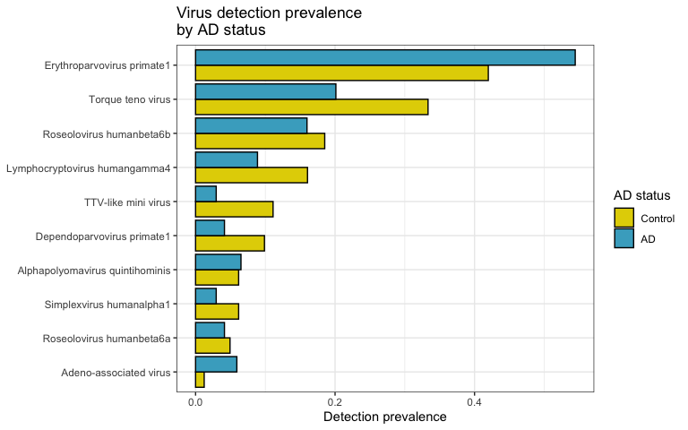

```r
# prevalence by AD status
ad_prev_p <- pa |>
  group_by(sp_short, AD_status) |>
  summarise(prev = mean(present), .groups = "drop") |>
  ggplot(aes(reorder(sp_short, prev), prev, fill = AD_status)) +
  geom_col(position = position_dodge(), color = "black") +
  scale_fill_manual(values = c(
    "#E2D200", "#46ACC8"
  )) +
  coord_flip() +
  labs(x = NULL, y = "Detection prevalence", fill = "AD status",
       title = "Virus detection prevalence\nby AD status") +
  theme_bw()
ad_prev_p
```

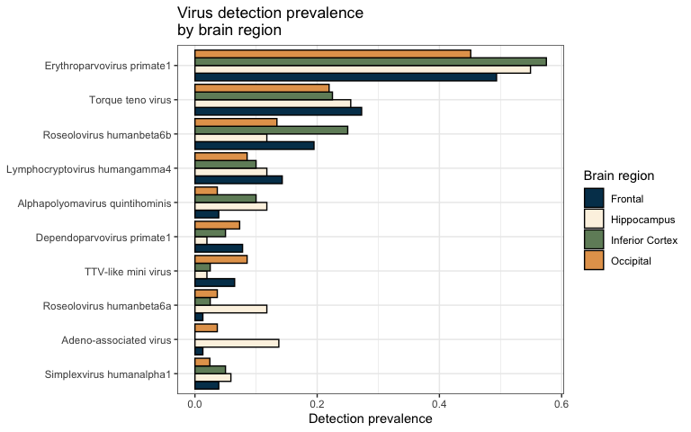

```r
# prevalence by brain region
tissue_prev_p <- pa |>
  group_by(sp_short, tissue) |>
  summarise(prev = mean(present), .groups = "drop") |>
  ggplot(aes(reorder(sp_short, prev), prev, fill = tissue)) +
  geom_col(position = position_dodge(), color = "black") +
  scale_fill_manual(values = c(
    "#013D5A", "#FCF3E3", "#708C69", "#E4A25B"
  )) +
  coord_flip() +
  labs(x = NULL, y = "Detection prevalence", fill = "Brain region",
       title = "Virus detection prevalence\nby brain region") +
  theme_bw()
tissue_prev_p
```

```r
ggsave(
  here::here("charts/AD_status_virus_prev_col1.pdf"),
  ad_prev_p,
  width = 5,
  height = 4
)
```

```r
ggsave(
  here::here("charts/brain_tissue_virus_prev_col1.pdf"),
  tissue_prev_p,
  width = 5,
  height = 4
)
```

## Association testing

Three complementary tests per species, FDR-corrected (Benjamini-Hochberg) across species within each variable:

- **tissue** — sample-level variable, tested with Fisher’s exact test on presence x region.
- **AD_status / age_at_death** — donor-level variables. Because most donors contribute >1 sample, we test these two ways:
  - **(A) donor aggregation** — collapse to one observation per donor (present if detected in ANY region), then Fisher (AD) / logistic (age).
  - **(B) mixed-effects GLMM** — sample-level logistic regression with a random intercept per donor, adjusting AD, age, and tissue simultaneously.

```r
library(purrr)
library(broom)
library(lme4)
library(broom.mixed)
```

### Tissue (sample level)

```r
tissue_res <- map_dfr(focal_species$species, function(sp) {
  d  <- filter(pa, species == sp)
  ft <- fisher.test(table(d$tissue, d$present),
                    simulate.p.value = TRUE, B = 1e4)
  tibble(species = gsub("^s__", "", sp), test = "Fisher presence~tissue",
         p.value = ft$p.value)
}) |>
  mutate(p.adj = p.adjust(p.value, "BH")) |>
  arrange(p.value)
tissue_res
```

| species | test | p.value | p.adj |
| --- | --- | --- | --- |
| Adeno-associated virus | Fisher presence~tissue | 0.00519948 | 0.0519948 |
| Roseolovirus humanbeta6a | Fisher presence~tissue | 0.05099490 | 0.2549745 |
| Alphapolyomavirus quintihominis | Fisher presence~tissue | 0.14928507 | 0.4976169 |
| Roseolovirus humanbeta6b | Fisher presence~tissue | 0.26997300 | 0.6749325 |
| TTV-like mini virus | Fisher presence~tissue | 0.38876112 | 0.7690660 |
| Dependoparvovirus primate1 | Fisher presence~tissue | 0.53474653 | 0.7690660 |
| Erythroparvovirus primate1 | Fisher presence~tissue | 0.53834617 | 0.7690660 |
| Simplexvirus humanalpha1 | Fisher presence~tissue | 0.70412959 | 0.7880323 |
| Lymphocryptovirus humangamma4 | Fisher presence~tissue | 0.70922908 | 0.7880323 |
| Torque teno virus | Fisher presence~tissue | 0.87191281 | 0.8719128 |

```r
pa |>
  filter(species == "s__Adeno-associated virus") |>
  group_by(tissue) |>
  summarise(total_present = sum(present), n_specimens = n())
```

| tissue | total_present | n_specimens |
| --- | --- | --- |
| Frontal | 1 | 77 |
| Hippocampus | 7 | 51 |
| Inferior Cortex | 0 | 40 |
| Occipital | 3 | 82 |

### AD status & age — (A) donor-aggregated

```r
donor_covars <- sample_meta |>
  group_by(donor) |>
  summarise(
    across(c(AD_status, age_at_death, braak_score, sex, biobank), first),
    n_regions = n(),
    .groups = "drop"
  )

donor_pa <- pa |>
  group_by(donor, species) |>
  summarise(present = as.integer(any(present == 1)), .groups = "drop") |>
  left_join(donor_covars, by = "donor")

donor_res <- map_dfr(focal_species$species, function(sp) {
  d  <- filter(donor_pa, species == sp)
  ft <- fisher.test(table(d$AD_status, d$present))         # AD: donor-level OR
  gl <- glm(present ~ age_at_death, data = d, family = binomial)  # age
  glbraak <- glm(present ~ braak_score, data = d, family = binomial)  # braak
  age_row <- coef(summary(gl))["age_at_death", ]
  braak_row <- coef(summary(glbraak))["braak_score", ]

  tibble(
    species       = gsub("^s__", "", sp),
    AD_OR         = unname(ft$estimate),
    AD_p          = ft$p.value,
    age_OR_per_yr = unname(exp(coef(gl)["age_at_death"])),
    age_p         = unname(age_row["Pr(>|z|)"]),
    braak_OR_per_stage = unname(exp(coef(glbraak)["braak_score"])),
    braak_p            = unname(braak_row["Pr(>|z|)"])
  )
}) |>
  mutate(AD_p.adj  = p.adjust(AD_p,  "BH"),
         age_p.adj = p.adjust(age_p, "BH"),
         braak_p.adj = p.adjust(braak_p, "BH")) |>
  arrange(AD_p)
donor_res
```

| species | AD_OR | AD_p | age_OR_per_yr | age_p | braak_OR_per_stage | braak_p | AD_p.adj | age_p.adj | braak_p.adj |
| --- | --- | --- | --- | --- | --- | --- | --- | --- | --- |
| Torque teno virus | 0.4240971 | 0.06529855 | 1.0073424 | 0.7633609 | 0.8194152 | 0.10804152 | 0.5872102 | 0.9702952 | 0.5192844 |
| TTV-like mini virus | 0.3678833 | 0.14847030 | 0.9601370 | 0.2670483 | 0.6529714 | 0.02000946 | 0.5872102 | 0.6676208 | 0.2000946 |
| Dependoparvovirus primate1 | 0.3773740 | 0.22462183 | 0.9428127 | 0.1360496 | 0.7572124 | 0.15578531 | 0.5872102 | 0.6262632 | 0.5192844 |
| Adeno-associated virus | 3.5213543 | 0.27848241 | 1.0704889 | 0.1066560 | 0.9381111 | 0.77090501 | 0.5872102 | 0.6262632 | 0.8565611 |
| Erythroparvovirus primate1 | 1.6716654 | 0.34858490 | 1.0334758 | 0.1878789 | 1.1575722 | 0.23681999 | 0.5872102 | 0.6262632 | 0.5508379 |
| Simplexvirus humanalpha1 | 0.3865824 | 0.35232615 | 1.0026624 | 0.9561474 | 1.0980215 | 0.69823656 | 0.5872102 | 0.9702952 | 0.8565611 |
| Lymphocryptovirus humangamma4 | 0.7739645 | 0.60098778 | 0.9984132 | 0.9549227 | 1.0168120 | 0.90384108 | 0.8585540 | 0.9702952 | 0.9038411 |
| Alphapolyomavirus quintihominis | 0.7955842 | 0.74093478 | 1.0355054 | 0.3367922 | 0.8759487 | 0.43996953 | 0.9261685 | 0.6735844 | 0.6285279 |
| Roseolovirus humanbeta6a | 1.4712235 | 1.00000000 | 1.0310939 | 0.4526284 | 0.7444018 | 0.30159156 | 1.0000000 | 0.7543806 | 0.5508379 |
| Roseolovirus humanbeta6b | 0.9704858 | 1.00000000 | 0.9991002 | 0.9702952 | 1.1278333 | 0.33050277 | 1.0000000 | 0.9702952 | 0.5508379 |

```r
write.table(
  donor_res,
  file = here::here("summary_tables/donor_virus_odds_ratios.csv"),
  sep = ",",
  quote = F,
  row.names = F
)
```

### AD status & age — (B) mixed-effects GLMM

**Sparse species cause complete separation** (huge or vanishingly small SEs and spurious p ~ 0). We therefore (a) only fit the GLMM to species with enough detections, and (b) flag any remaining fit whose SE is implausible as unreliable and exclude it from FDR correction.

```r
glmm_min_detect <- 25  # GLMM needs a reasonable number of positives

glmm_species <- focal_species |> filter(n_detected >= glmm_min_detect) |> pull(species)

glmm_res <- map_dfr(glmm_species, function(sp) {
  d <- filter(pa, species == sp)
  m <- tryCatch(
    glmer(present ~ AD_status + scale(age_at_death) + tissue + (1 | donor),
          data = d, family = binomial,
          control = glmerControl(optimizer = "bobyqa",
                                  optCtrl = list(maxfun = 2e5))),
    error = function(e) NULL
  )
  if (is.null(m)) {
    return(tibble(species = gsub("^s__", "", sp),
                  term = c("AD_statusAD", "scale(age_at_death)"),
                  estimate = NA_real_, std.error = NA_real_, p.value = NA_real_))
  }
  broom.mixed::tidy(m, effects = "fixed") |>
    filter(term %in% c("AD_statusAD", "scale(age_at_death)")) |>
    transmute(species = gsub("^s__", "", sp), term, estimate, std.error, p.value)
}) |>
  # guard against separation: trust only plausibly-scaled SEs
  mutate(reliable = is.finite(std.error) & std.error > 0.05 & std.error < 5) |>
  group_by(term) |>
  mutate(p.adj = ifelse(reliable, p.adjust(ifelse(reliable, p.value, NA), "BH"), NA_real_)) |>
  ungroup() |>
  arrange(term, p.value)
glmm_res
```

| species | term | estimate | std.error | p.value | reliable | p.adj |
| --- | --- | --- | --- | --- | --- | --- |
| Erythroparvovirus primate1 | AD_statusAD | 0.65635738 | 0.5239687 | 0.2103275 | TRUE | 0.7591569 |
| Lymphocryptovirus humangamma4 | AD_statusAD | -0.75415992 | 0.8582939 | 0.3795785 | TRUE | 0.7591569 |
| Torque teno virus | AD_statusAD | -0.92576931 | 1.6440131 | 0.5733562 | TRUE | 0.7644750 |
| Roseolovirus humanbeta6b | AD_statusAD | -0.10561924 | 0.4276783 | 0.8049395 | TRUE | 0.8049395 |
| Erythroparvovirus primate1 | scale(age_at_death) | 0.27487415 | 0.2302086 | 0.2324693 | TRUE | 0.7279523 |
| Roseolovirus humanbeta6b | scale(age_at_death) | 0.16389294 | 0.1990503 | 0.4102951 | TRUE | 0.7279523 |
| Torque teno virus | scale(age_at_death) | 0.51064139 | 0.8456866 | 0.5459642 | TRUE | 0.7279523 |
| Lymphocryptovirus humangamma4 | scale(age_at_death) | -0.03941818 | 0.3828468 | 0.9179942 | TRUE | 0.9179942 |

```r
write.table(
  glmm_res,
  file = here::here("summary_tables/donor_mixed_effects_glmm.csv"),
  sep = ",",
  quote = F,
  row.names = F
)
```

### Combined summary

```r
summary_tbl <- donor_res |>
  select(species, AD_OR, AD_p.adj, age_OR_per_yr, age_p.adj) |>
  left_join(
    glmm_res |>
      pivot_wider(id_cols = species, names_from = term,
                  values_from = c(estimate, p.adj)),
    by = "species"
  ) |>
  left_join(tissue_res |> select(species, tissue_p.adj = p.adj),
            by = "species") |>
  arrange(AD_p.adj)
summary_tbl
```

| species | AD_OR | AD_p.adj | age_OR_per_yr | age_p.adj | estimate_AD_statusAD | estimate_scale(age_at_death) | p.adj_AD_statusAD | p.adj_scale(age_at_death) | tissue_p.adj |
| --- | --- | --- | --- | --- | --- | --- | --- | --- | --- |
| Torque teno virus | 0.4240971 | 0.5872102 | 1.0073424 | 0.9702952 | -0.9257693 | 0.51064145 | 0.7644611 | 0.7279496 | 0.8678132 |
| TTV-like mini virus | 0.3678833 | 0.5872102 | 0.9601370 | 0.6676208 | NA | NA | NA | NA | 0.7610668 |
| Dependoparvovirus primate1 | 0.3773740 | 0.5872102 | 0.9428127 | 0.6262632 | NA | NA | NA | NA | 0.7610668 |
| Adeno-associated virus | 3.5213543 | 0.5872102 | 1.0704889 | 0.6262632 | NA | NA | NA | NA | 0.0399960 |
| Erythroparvovirus primate1 | 1.6716654 | 0.5872102 | 1.0334758 | 0.6262632 | 0.6563588 | 0.27487412 | 0.7591619 | 0.7279496 | 0.7610668 |
| Simplexvirus humanalpha1 | 0.3865824 | 0.5872102 | 1.0026624 | 0.9702952 | NA | NA | NA | NA | 0.7945872 |
| Lymphocryptovirus humangamma4 | 0.7739645 | 0.8585540 | 0.9984132 | 0.9702952 | -0.7541597 | -0.03941807 | 0.7591619 | 0.9179946 | 0.7945872 |
| Alphapolyomavirus quintihominis | 0.7955842 | 0.9261685 | 1.0355054 | 0.6735844 | NA | NA | NA | NA | 0.5042829 |
| Roseolovirus humanbeta6a | 1.4712235 | 1.0000000 | 1.0310939 | 0.7543806 | NA | NA | NA | NA | 0.2514749 |
| Roseolovirus humanbeta6b | 0.9704858 | 1.0000000 | 0.9991002 | 0.9702952 | -0.1056193 | 0.16389299 | 0.8049394 | 0.7279496 | 0.6824318 |

## Abundance-based tests (two-part / hurdle framing)

Viral abundance is zero-inflated, so we treat it as a **two-part (hurdle)** process and keep the two parts separate:

- **Part 1 - prevalence:** is the virus *detected* at different rates? This is already covered by the presence/absence tests above (Fisher / GLMM).
- **Part 2 - load given presence:** *among samples where the virus is detected*, is the abundance (`RPKMF`) higher? This is the section below. We drop zeros here **on purpose** so this arm reflects load only, not prevalence.

**Caveat (selection / collider bias):** conditioning on detection means the positive subgroups being compared are not the full randomised groups; if a variable also shifts prevalence, the conditional-load comparison can be biased. The conditional estimand is “among infected samples,” which is a valid but narrower question. To make the logic transparent we therefore **also run unconditional tests that include the zeros** (see the sensitivity subsection at the end); those combine prevalence + load into a single abundance shift.

Donor-level variables (AD, age) are aggregated to the mean per-donor abundance to respect the repeated-measures structure.

```r
# positive samples only, with abundance
pos <- pa |> filter(present == 1)

# donor-level mean abundance among positive samples (for AD/age)
donor_abund <- pos |>
  group_by(donor, species, sp_short, AD_status, age_at_death, braak_score) |>
  summarise(mean_RPKMF = mean(RPKMF), .groups = "drop")
```

### Tissue - Kruskal-Wallis on abundance (positive samples)

```r
abund_tissue_res <- map_dfr(focal_species$species, function(sp) {
  d <- filter(pos, species == sp)
  # need >=2 regions each with >=2 positive samples for a meaningful test
  ok <- d |> count(tissue) |> filter(n >= 2) |> nrow()
  if (ok < 2) {
    return(tibble(species = gsub("^s__", "", sp), n_pos = nrow(d),
                  p.value = NA_real_))
  }
  kw <- kruskal.test(RPKMF ~ tissue, data = d)
  tibble(species = gsub("^s__", "", sp), n_pos = nrow(d), p.value = kw$p.value)
}) |>
  mutate(p.adj = p.adjust(p.value, "BH")) |>
  arrange(p.value)
abund_tissue_res
```

| species | n_pos | p.value | p.adj |
| --- | --- | --- | --- |
| Erythroparvovirus primate1 | 126 | 0.01944431 | 0.1944431 |
| Roseolovirus humanbeta6a | 11 | 0.04632588 | 0.2316294 |
| Dependoparvovirus primate1 | 15 | 0.18182490 | 0.5385271 |
| Lymphocryptovirus humangamma4 | 28 | 0.22844318 | 0.5385271 |
| Roseolovirus humanbeta6b | 42 | 0.32833596 | 0.5385271 |
| Simplexvirus humanalpha1 | 10 | 0.33152972 | 0.5385271 |
| Torque teno virus | 61 | 0.37696898 | 0.5385271 |
| Adeno-associated virus | 11 | 0.53845701 | 0.6730713 |
| Alphapolyomavirus quintihominis | 16 | 0.63807871 | 0.7089763 |
| TTV-like mini virus | 14 | 0.71975376 | 0.7197538 |

```r
write.table(
  abund_tissue_res,
  file = here::here("summary_tables/tissue_abundance_detected_only.csv"),
  sep = ",",
  quote = F,
  row.names = F
)
```

### AD status - Wilcoxon on donor-level abundance (positive donors)

```r
abund_ad_res <- map_dfr(focal_species$species, function(sp) {
  d   <- filter(donor_abund, species == sp)
  grp <- d |> count(AD_status) |> filter(n >= 3)
  if (nrow(grp) < 2) {
    return(tibble(species = gsub("^s__", "", sp), n_pos_donor = nrow(d),
                  p.value = NA_real_))
  }
  wt <- wilcox.test(mean_RPKMF ~ AD_status, data = d, exact = FALSE)
  tibble(species = gsub("^s__", "", sp), n_pos_donor = nrow(d),
         p.value = wt$p.value)
}) |>
  mutate(p.adj = p.adjust(p.value, "BH")) |>
  arrange(p.value)
abund_ad_res
```

| species | n_pos_donor | p.value | p.adj |
| --- | --- | --- | --- |
| Erythroparvovirus primate1 | 67 | 0.007521535 | 0.06017228 |
| Roseolovirus humanbeta6b | 34 | 0.100146160 | 0.29960319 |
| Dependoparvovirus primate1 | 8 | 0.112351198 | 0.29960319 |
| Torque teno virus | 34 | 0.587551923 | 0.77268950 |
| Simplexvirus humanalpha1 | 6 | 0.662520584 | 0.77268950 |
| Alphapolyomavirus quintihominis | 12 | 0.671125458 | 0.77268950 |
| TTV-like mini virus | 10 | 0.676103314 | 0.77268950 |
| Lymphocryptovirus humangamma4 | 21 | 0.852043446 | 0.85204345 |
| Adeno-associated virus | 9 | NA | NA |
| Roseolovirus humanbeta6a | 9 | NA | NA |

```r
write.table(
  abund_tissue_res,
  file = here::here("summary_tables/AD_status_abundance_detected_only.csv"),
  sep = ",",
  quote = F,
  row.names = F
)
```

### Age at death - Spearman correlation (positive donors)

```r
abund_age_res <- map_dfr(focal_species$species, function(sp) {
  d <- filter(donor_abund, species == sp)
  if (nrow(d) < 5) {
    return(tibble(species = gsub("^s__", "", sp), n_pos_donor = nrow(d),
                  rho = NA_real_, p.value = NA_real_))
  }
  ct <- suppressWarnings(
    cor.test(d$age_at_death, d$mean_RPKMF, method = "spearman"))
  tibble(species = gsub("^s__", "", sp), n_pos_donor = nrow(d),
         rho = unname(ct$estimate), p.value = ct$p.value)
}) |>
  mutate(p.adj = p.adjust(p.value, "BH")) |>
  arrange(p.value)
abund_age_res
```

| species | n_pos_donor | rho | p.value | p.adj |
| --- | --- | --- | --- | --- |
| Roseolovirus humanbeta6a | 9 | -0.69631062 | 0.03718338 | 0.3718338 |
| TTV-like mini virus | 10 | -0.48171627 | 0.15860575 | 0.5353573 |
| Erythroparvovirus primate1 | 67 | 0.17336923 | 0.16060718 | 0.5353573 |
| Dependoparvovirus primate1 | 8 | 0.35928788 | 0.38206468 | 0.7977064 |
| Lymphocryptovirus humangamma4 | 21 | -0.18483615 | 0.42249122 | 0.7977064 |
| Roseolovirus humanbeta6b | 34 | -0.12572909 | 0.47862386 | 0.7977064 |
| Simplexvirus humanalpha1 | 6 | 0.31428571 | 0.56388889 | 0.8055556 |
| Alphapolyomavirus quintihominis | 12 | -0.11247960 | 0.72781129 | 0.8769729 |
| Adeno-associated virus | 9 | -0.08403658 | 0.82980641 | 0.8769729 |
| Torque teno virus | 34 | 0.02757574 | 0.87697291 | 0.8769729 |

```r
write.table(
  abund_age_res,
  file = here::here("summary_tables/age_abundance_detected_only.csv"),
  sep = ",",
  quote = F,
  row.names = F
)
```

### Braak score - Spearman correlation (positive donors)

```r
abund_braak_res <- map_dfr(focal_species$species, function(sp) {
  d <- filter(donor_abund, species == sp) |> filter(!is.na(braak_score))
  if (nrow(d) < 5) {
    return(tibble(species = gsub("^s__", "", sp), n_pos_donor = nrow(d),
                  rho = NA_real_, p.value = NA_real_))
  }
  ct <- suppressWarnings(
    cor.test(d$braak_score, d$mean_RPKMF, method = "spearman"))
  tibble(species = gsub("^s__", "", sp), n_pos_donor = nrow(d),
         rho = unname(ct$estimate), p.value = ct$p.value)
}) |>
  mutate(p.adj = p.adjust(p.value, "BH")) |>
  arrange(p.value)
abund_braak_res
```

| species | n_pos_donor | rho | p.value | p.adj |
| --- | --- | --- | --- | --- |
| Erythroparvovirus primate1 | 57 | -0.26327094 | 0.04785261 | 0.4306735 |
| Roseolovirus humanbeta6b | 33 | 0.17986104 | 0.31654546 | 0.8458234 |
| Adeno-associated virus | 6 | 0.44136741 | 0.38093921 | 0.8458234 |
| Dependoparvovirus primate1 | 7 | -0.37424059 | 0.40820943 | 0.8458234 |
| Simplexvirus humanalpha1 | 6 | -0.37032804 | 0.46990186 | 0.8458234 |
| Alphapolyomavirus quintihominis | 10 | 0.14770979 | 0.68384281 | 0.9413601 |
| Torque teno virus | 28 | -0.06768948 | 0.73216894 | 0.9413601 |
| Lymphocryptovirus humangamma4 | 20 | 0.03544991 | 0.88204708 | 0.9651734 |
| TTV-like mini virus | 9 | -0.01709964 | 0.96517339 | 0.9651734 |
| Roseolovirus humanbeta6a | 3 | NA | NA | NA |

```r
write.table(
  abund_braak_res,
  file = here::here("summary_tables/braak_abundance_detected_only.csv"),
  sep = ",",
  quote = F,
  row.names = F
)
```

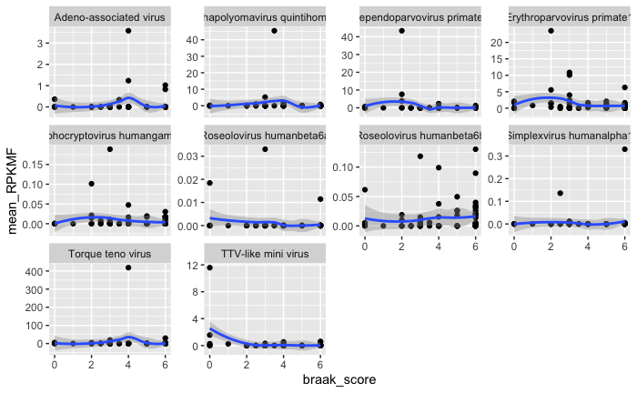

```r
donor_abund |>
  filter(!is.na(braak_score)) |>
  complete(nesting(donor, braak_score), sp_short, fill = list(mean_RPKMF = 0)) |>
  ggplot(aes(x = braak_score, y = mean_RPKMF)) +
  geom_point() +
  geom_smooth() +
  facet_wrap(~sp_short, scales = "free_y")
```

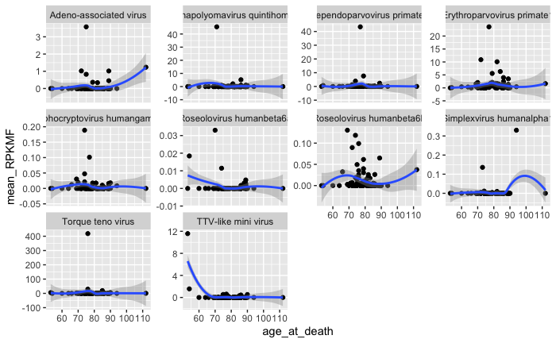

```r
donor_abund |>
  filter(!is.na(age_at_death)) |>
  complete(nesting(donor, age_at_death), sp_short, fill = list(mean_RPKMF = 0)) |>
  ggplot(aes(x = age_at_death, y = mean_RPKMF)) +
  geom_point() +
  geom_smooth() +
  facet_wrap(~sp_short, scales = "free_y")
```

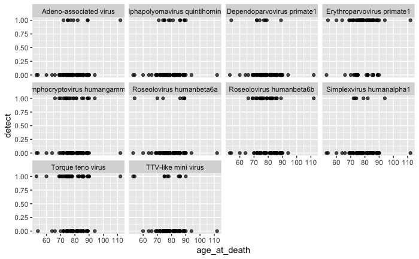

```r
donor_abund |>
  filter(!is.na(age_at_death)) |>
  complete(nesting(donor, age_at_death), sp_short, fill = list(mean_RPKMF = 0)) |>
  mutate(detect = case_when(
    mean_RPKMF > 0 ~ 1,
    TRUE ~ 0
  )) |>
  ggplot(aes(x = age_at_death, y = detect)) +
  geom_point(alpha = 0.7) +
  facet_wrap(~sp_short)
```

### Braak score - donor-level detection

Detection is positive if a virus occurs in any sampled region. Models adjust for age, sex, biobank, and number of regions; diagnosis is omitted because it is nearly collinear with Braak score. Some donors span pools, so biobank is the donor-level batch covariate.

```r
braak_min_detect <- 25
braak_species <- focal_species |>
  filter(n_detected >= braak_min_detect) |>
  pull(species)

braak_detection <- donor_pa |>
  filter(species %in% braak_species, !is.na(braak_score)) |>
  mutate(sp_short = gsub("^s__", "", species))

braak_models <- set_names(braak_species) |>
  map(~ glm(
    present ~ braak_score + scale(age_at_death) + sex + biobank + n_regions,
    data = filter(braak_detection, species == .x),
    family = binomial
  ))

extract_braak <- function(m, sp) {
  broom::tidy(m) |>
    filter(term == "braak_score") |>
    transmute(
      species = gsub("^s__", "", sp),
      n_donor = nobs(m),
      n_detected = sum(model.response(model.frame(m))),
      OR_per_stage = exp(estimate),
      conf.low = exp(estimate - 1.96 * std.error),
      conf.high = exp(estimate + 1.96 * std.error),
      p.value
    )
}

braak_detection_res <- imap_dfr(braak_models, ~ extract_braak(.x, .y)) |>
  mutate(p.adj = p.adjust(p.value, "BH")) |>
  arrange(p.value)
braak_detection_res
```

| species | n_donor | n_detected | OR_per_stage | conf.low | conf.high | p.value | p.adj |
| --- | --- | --- | --- | --- | --- | --- | --- |
| Torque teno virus | 84 | 28 | 0.7200008 | 0.5405598 | 0.9590079 | 0.02469134 | 0.09876537 |
| Roseolovirus humanbeta6b | 84 | 33 | 1.1756000 | 0.8914621 | 1.5503018 | 0.25176345 | 0.50352691 |
| Lymphocryptovirus humangamma4 | 84 | 20 | 0.9359048 | 0.6879096 | 1.2733036 | 0.67321948 | 0.88164482 |
| Erythroparvovirus primate1 | 84 | 57 | 1.0227387 | 0.7607056 | 1.3750320 | 0.88164482 | 0.88164482 |

```r
write.table(
  braak_detection_res,
  file = here::here("summary_tables/braak_virus_presence_glm.csv"),
  sep = ",",
  quote = F,
  row.names = F
)
```

```r
braak_3region_models <- set_names(braak_species) |>
  map(~ glm(
    present ~ braak_score + scale(age_at_death) + sex + biobank,
    data = filter(braak_detection, species == .x, n_regions == 3),
    family = binomial
  ))

braak_3region_res <- imap_dfr(
  braak_3region_models,
  ~ extract_braak(.x, .y)
) |>
  mutate(p.adj = p.adjust(p.value, "BH")) |>
  arrange(p.value)
braak_3region_res
```

| species | n_donor | n_detected | OR_per_stage | conf.low | conf.high | p.value | p.adj |
| --- | --- | --- | --- | --- | --- | --- | --- |
| Torque teno virus | 70 | 24 | 0.7316748 | 0.5333929 | 1.003665 | 0.05270713 | 0.2108285 |
| Lymphocryptovirus humangamma4 | 70 | 18 | 0.8870728 | 0.6313502 | 1.246374 | 0.48979213 | 0.9143639 |
| Roseolovirus humanbeta6b | 70 | 29 | 1.0643839 | 0.7867300 | 1.440028 | 0.68577293 | 0.9143639 |
| Erythroparvovirus primate1 | 70 | 52 | 1.0182502 | 0.7306554 | 1.419046 | 0.91494522 | 0.9149452 |

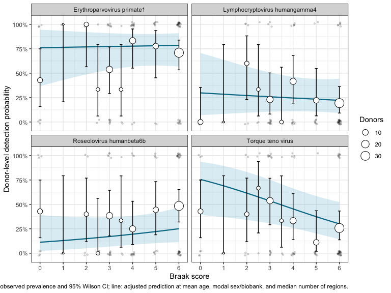

```r
braak_stage_prev <- braak_detection |>
  group_by(sp_short, braak_score) |>
  summarise(n = n(), n_detected = sum(present), prev = mean(present), .groups = "drop") |>
  mutate(
    z = qnorm(0.975),
    center = (prev + z^2 / (2 * n)) / (1 + z^2 / n),
    half = z * sqrt(prev * (1 - prev) / n + z^2 / (4 * n^2)) / (1 + z^2 / n),
    conf.low = pmax(0, center - half),
    conf.high = pmin(1, center + half)
  )

braak_predictions <- imap_dfr(braak_models, function(m, sp) {
  d <- filter(braak_detection, species == sp)
  nd <- tibble(
    braak_score = seq(0, 6, by = 0.1),
    age_at_death = mean(d$age_at_death),
    sex = factor(names(sort(table(d$sex), decreasing = TRUE))[1], levels = levels(d$sex)),
    biobank = factor(names(sort(table(d$biobank), decreasing = TRUE))[1],
                     levels = levels(d$biobank)),
    n_regions = median(d$n_regions)
  )
  pr <- predict(m, newdata = nd, type = "link", se.fit = TRUE)
  nd |>
    transmute(
      sp_short = gsub("^s__", "", sp), braak_score,
      estimate = plogis(pr$fit),
      conf.low = plogis(pr$fit - 1.96 * pr$se.fit),
      conf.high = plogis(pr$fit + 1.96 * pr$se.fit)
    )
})

set.seed(1)
braak_detection_p <- ggplot() +
  geom_ribbon(
    data = braak_predictions,
    aes(braak_score, ymin = conf.low, ymax = conf.high),
    fill = "#46ACC8", alpha = 0.2
  ) +
  geom_line(
    data = braak_predictions,
    aes(braak_score, estimate),
    color = "#007A95", linewidth = 0.8
  ) +
  geom_jitter(
    data = braak_detection,
    aes(braak_score, present),
    width = 0.08, height = 0.025, alpha = 0.15, size = 0.8
  ) +
  geom_errorbar(
    data = braak_stage_prev,
    aes(braak_score, ymin = conf.low, ymax = conf.high),
    width = 0.12
  ) +
  geom_point(
    data = braak_stage_prev,
    aes(braak_score, prev, size = n),
    shape = 21, fill = "white"
  ) +
  facet_wrap(~sp_short) +
  scale_x_continuous(breaks = 0:6) +
  scale_y_continuous(breaks = seq(0, 1, 0.25), labels = scales::percent) +
  coord_cartesian(ylim = c(-0.04, 1.04)) +
  labs(
    x = "Braak score", y = "Donor-level detection probability",
    size = "Donors",
    caption = paste(
      "Points and intervals: observed prevalence and 95% Wilson CI; line: adjusted prediction",
      "at mean age, modal sex/biobank, and median number of regions."
    )
  ) +
  theme_bw()
braak_detection_p
```

```r
ggsave(
  here::here("charts/braak_score_donor_detection.pdf"),
  braak_detection_p,
  width = 8,
  height = 6
)
```

```r
sample_meta |>
  ggplot(aes(x = age_at_death, y = braak_score)) +
  geom_point() +
  geom_smooth()
```

[output not shown]

### Abundance distributions (positive samples)

```r
ad_ab_box_p <- ggplot(pos, aes(AD_status, RPKMF)) +
  geom_boxplot(outlier.size = 0.5) +
  geom_jitter(width = 0.15, alpha = 0.3, size = 0.6) +
  scale_y_log10() +
  facet_wrap(~ sp_short, scales = "free_y") +
  labs(x = "AD status", y = "RPKMF (log10, positives only)",
       title = "Abundance by AD status") +
  theme_bw()
ad_ab_box_p

tissue_ab_box_p <- ggplot(pos, aes(tissue, RPKMF)) +
  geom_boxplot(outlier.size = 0.5) +
  geom_jitter(width = 0.15, alpha = 0.3, size = 0.6) +
  scale_y_log10() +
  facet_wrap(~ sp_short, scales = "free_y") +
  labs(x = "Brain region", y = "RPKMF (log10, positives only)",
       title = "Abundance by brain region") +
  theme_bw() +
  theme(axis.text.x = element_text(angle = 30, hjust = 1))
tissue_ab_box_p
```

[output not shown]

```r
ggsave(
  here::here("charts/ad_status_ab_box1.pdf"),
  ad_ab_box_p,
  width = 9,
  height = 3.5
)
```

```r
ggsave(
  here::here("charts/tissue_ab_box1.pdf"),
  tissue_ab_box_p,
  width = 9,
  height = 3.5
)
```

### Sensitivity: unconditional tests (zeros included)

Here we repeat the same non-parametric tests but **keep the zeros** (all analysis samples, absence = `RPKMF` 0). These answer the combined question “is overall abundance shifted?”, mixing prevalence and load. Agreement with the conditional results argues the conditioning did not distort the picture; divergence flags that a signal is driven by prevalence rather than load.

```r
# all samples (zeros included); donor-level mean over ALL that donor's samples
donor_abund_all <- pa |>
  group_by(donor, species, sp_short, AD_status, age_at_death) |>
  summarise(mean_RPKMF = mean(RPKMF), .groups = "drop")  # includes zeros
```

```r
# tissue: Kruskal-Wallis on ALL samples (zeros included)
abund_tissue_all <- map_dfr(focal_species$species, function(sp) {
  d  <- filter(pa, species == sp)
  kw <- kruskal.test(RPKMF ~ tissue, data = d)
  tibble(species = gsub("^s__", "", sp), p.value = kw$p.value)
}) |>
  mutate(p.adj = p.adjust(p.value, "BH")) |>
  arrange(p.value)
abund_tissue_all
```

[output not shown]

```r
# AD: Wilcoxon on donor-level mean abundance (zeros included)
abund_ad_all <- map_dfr(focal_species$species, function(sp) {
  d  <- filter(donor_abund_all, species == sp)
  wt <- wilcox.test(mean_RPKMF ~ AD_status, data = d, exact = FALSE)
  tibble(species = gsub("^s__", "", sp), p.value = wt$p.value)
}) |>
  mutate(p.adj = p.adjust(p.value, "BH")) |>
  arrange(p.value)
abund_ad_all
```

[output not shown]

```r
# age: Spearman on donor-level mean abundance (zeros included)
abund_age_all <- map_dfr(focal_species$species, function(sp) {
  d  <- filter(donor_abund_all, species == sp)
  ct <- suppressWarnings(
    cor.test(d$age_at_death, d$mean_RPKMF, method = "spearman"))
  tibble(species = gsub("^s__", "", sp), rho = unname(ct$estimate),
         p.value = ct$p.value)
}) |>
  mutate(p.adj = p.adjust(p.value, "BH")) |>
  arrange(p.value)
abund_age_all
```

[output not shown]

```r
# side-by-side: conditional (positives only) vs unconditional (zeros included)
abund_compare_ad <- abund_ad_res |>
  select(species, p.adj_conditional = p.adj) |>
  full_join(abund_ad_all |> select(species, p.adj_unconditional = p.adj),
            by = "species") |>
  arrange(p.adj_unconditional)
abund_compare_ad
```

[output not shown]

# Diversity analysis (vegan)

```r
library(vegan)

sample_meta2 <- sample_meta |> mutate(sample = paste(sample_ID, Pool, sep = "."))

# sample x species abundance matrix (RPKMF), all species, zeros filled
comm_mat <- det |>
  transmute(sample = paste(sample_ID, Pool, sep = "."), species, RPKMF) |>
  tidyr::pivot_wider(names_from = species, values_from = RPKMF, values_fill = 0) |>
  tibble::column_to_rownames("sample")

# add all-zero rows for viral-negative samples, then order to metadata
missing_samples <- setdiff(sample_meta2$sample, rownames(comm_mat))
if (length(missing_samples)) {
  zero_block <- matrix(0, nrow = length(missing_samples), ncol = ncol(comm_mat),
                       dimnames = list(missing_samples, colnames(comm_mat)))
  comm_mat <- rbind(comm_mat, as.data.frame(zero_block))
}
comm_mat <- as.matrix(comm_mat[sample_meta2$sample, , drop = FALSE])

dim(comm_mat)  # samples x species
```

[output not shown]

## Alpha diversity

```r
alpha_dt <- sample_meta2 |>
  mutate(richness = specnumber(comm_mat),
         shannon  = diversity(comm_mat, index = "shannon"))

# donor-level (mean across regions) so each donor counts once
alpha_donor <- alpha_dt |>
  group_by(donor, AD_status, age_at_death) |>
  summarise(richness = mean(richness), shannon = mean(shannon), .groups = "drop")

# AD status: Wilcoxon; age: Spearman
alpha_tests <- tibble::tibble(
  metric   = c("shannon", "richness", "shannon", "richness"),
  variable = c("AD_status", "AD_status", "age_at_death", "age_at_death"),
  p.value  = c(
    wilcox.test(shannon  ~ AD_status, data = alpha_donor, exact = FALSE)$p.value,
    wilcox.test(richness ~ AD_status, data = alpha_donor, exact = FALSE)$p.value,
    cor.test(alpha_donor$age_at_death, alpha_donor$shannon,  method = "spearman")$p.value,
    cor.test(alpha_donor$age_at_death, alpha_donor$richness, method = "spearman")$p.value
  )
)
alpha_tests
```

[output not shown]

```r
alpha_long <- tidyr::pivot_longer(alpha_donor, c(richness, shannon),
                                  names_to = "metric", values_to = "value")

alpha_ad_p <- ggplot(alpha_long, aes(AD_status, value, fill = AD_status)) +
  geom_boxplot(outlier.size = 0.5) +
  scale_fill_manual(values = c(
    "#E2D200", "#46ACC8"
  )) +
  facet_wrap(~ metric, scales = "free_y") +
  labs(x = "AD status", y = "Donor-level alpha diversity",
       title = "Alpha diversity by AD status") +
  theme_bw()
alpha_ad_p

alpha_age_p <- ggplot(alpha_long, aes(age_at_death, value)) +
  geom_point(alpha = 0.5, size = 0.8) +
  geom_smooth(method = "lm", se = TRUE) +
  facet_wrap(~ metric, scales = "free_y") +
  labs(x = "Age at death", y = "Donor-level alpha diversity",
       title = "Alpha diversity vs age") +
  theme_bw()
alpha_age_p
```

[output not shown]

```r
ggsave(
  here::here("charts/AD_status_alpha_box1.pdf"),
  alpha_ad_p,
  width = 5,
  height = 4
)
```

```r
ggsave(
  here::here("charts/age_alpha_scatter1.pdf"),
  alpha_age_p,
  width = 7,
  height = 3
)
```

## Beta diversity (PERMANOVA)

Donor-level community = sum of `RPKMF` across a donor’s regions, converted to relative abundance so total-magnitude effort is removed; `n_regions` still enters the model to absorb richness-effort effects. We use Bray-Curtis (abundance) and Jaccard (presence/absence). Empty (viral-negative) donors are dropped because these distances are undefined for all-zero communities.

```r
set.seed(1)

donor_map  <- setNames(sample_meta2$donor, sample_meta2$sample)
donor_comm <- rowsum(comm_mat, group = donor_map[rownames(comm_mat)])
n_reg      <- table(donor_map[rownames(comm_mat)])

keep <- rowSums(donor_comm) > 0            # drop viral-negative donors
dc   <- donor_comm[keep, , drop = FALSE]

md <- sample_meta2 |>
  distinct(donor, AD_status, age_at_death) |>
  mutate(n_regions = as.integer(n_reg[donor]))
md <- md[match(rownames(dc), md$donor), ]

cat("donors used for beta diversity:", nrow(dc),
    "  (dropped", sum(!keep), "viral-negative)\n")

dc_rel <- decostand(dc, method = "total")  # relative abundance per donor
bc     <- vegdist(dc_rel, method = "bray")
jac    <- vegdist(dc > 0, method = "jaccard")

# marginal PERMANOVA (each term adjusted for the others)
adonis_bray <- adonis2(bc ~ n_regions + AD_status + age_at_death,
                       data = md, by = "margin", permutations = 999)
adonis_jac  <- adonis2(jac ~ n_regions + AD_status + age_at_death,
                       data = md, by = "margin", permutations = 999)
adonis_bray
adonis_jac
```

[output not shown]

**Dispersion check (important here).** PERMANOVA can report a spurious “location” difference when groups have unequal size *and* unequal within-group dispersion - exactly our situation (many AD vs few controls). `betadisper` tests whether the groups differ in spread; a significant result means any PERMANOVA signal should be interpreted cautiously.

```r
set.seed(1)
bd <- betadisper(bc, md$AD_status)
permutest(bd, permutations = 999)
```

[output not shown]

```r
set.seed(1)
nmds <- metaMDS(dc_rel, distance = "bray", trymax = 50, trace = 0)

nmds_scores <- as.data.frame(vegan::scores(nmds, display = "sites")) |>
  tibble::rownames_to_column("donor") |>
  left_join(md, by = "donor")

ad_nmds_p <- ggplot(nmds_scores, aes(NMDS1, NMDS2, color = AD_status)) +
  geom_point(size = 2.5, alpha = 0.8) +
  stat_ellipse() +
  scale_color_manual(values = c(
    "#E2D200", "#46ACC8"
  )) +
  labs(title = sprintf("Bray-Curtis NMDS (stress = %.3f)", nmds$stress),
       colour = "AD status") +
  theme_bw()
ad_nmds_p

age_nmds_p <- ggplot(nmds_scores, aes(NMDS1, NMDS2, colour = age_at_death)) +
  geom_point(size = 2.5, alpha = 0.9) +
  scale_color_gradient2(low = "grey80", mid = "#FAD77B", high = "#972D15", midpoint = 80) +
  labs(title = "Bray-Curtis NMDS coloured by age", colour = "Age") +
  theme_bw()
age_nmds_p
```

[output not shown]

```r
ggsave(
  here::here("charts/AD_status_NMDS1.pdf"),
  ad_nmds_p,
  width = 5,
  height = 4
)
```

```r
ggsave(
  here::here("charts/age_NMDS1.pdf"),
  age_nmds_p,
  width = 5,
  height = 4
)
```

# Power / sample-size analysis (for future designs)

The AD and age effects are tested at the **donor** level (the effective sample size is the number of donors, not samples, because brain regions within a donor are repeated measures). The bottleneck is the **imbalance**: many AD donors but few non-AD controls. We quantify this two ways below.

```r
set.seed(1)

# effective (donor-level) group sizes actually used for the AD contrast
donor_tab <- sample_meta |> distinct(donor, AD_status) |> count(AD_status)
donor_tab
n_AD    <- donor_tab$n[donor_tab$AD_status == "AD"]
n_ctrl  <- donor_tab$n[donor_tab$AD_status == "Control"]
c(n_AD = n_AD, n_ctrl = n_ctrl)

# Monte-Carlo power for a Fisher's exact test comparing two prevalences.
# p_ctrl / p_ad = detection prevalence in each donor group.
power_fisher <- function(p_ctrl, p_ad, n_ctrl, n_ad,
                         nsim = 1000, alpha = 0.05) {
  mean(replicate(nsim, {
    x1 <- rbinom(1, n_ctrl, p_ctrl)
    x2 <- rbinom(1, n_ad,   p_ad)
    m  <- matrix(c(x1, n_ctrl - x1, x2, n_ad - x2), nrow = 2)
    fisher.test(m)$p.value < alpha
  }))
}
```

[output not shown]

## Minimum detectable effect for the AD contrast (current cohort)

```r
inv_or <- function(p1, or) (or * p1 / (1 - p1)) / (1 + or * p1 / (1 - p1))  # p2 from OR

mde_ad <- tidyr::crossing(
  p_ctrl = c(0.10, 0.25, 0.50),
  alpha  = c(0.05, 0.005),
  OR     = seq(1.5, 30, by = 0.5)
) |>
  mutate(p_ad  = inv_or(p_ctrl, OR),
         power = purrr::pmap_dbl(list(p_ctrl, p_ad, alpha),
                    ~ power_fisher(..1, ..2, n_ctrl, n_AD,
                                   nsim = 800, alpha = ..3))) |>
  group_by(p_ctrl, alpha) |>
  summarise(min_detectable_OR = {
    hit <- OR[power >= 0.80]
    if (length(hit)) min(hit) else NA_real_
  }, .groups = "drop")
mde_ad
```

[output not shown]

## Power vs cohort balance (design curve)

```r
balance_grid <- tidyr::crossing(
  n_ctrl_try = c(seq(10, 140, by = 10), n_ctrl),
  scenario   = c("modest (25% vs 40%)", "moderate (25% vs 50%)",
                 "large (25% vs 65%)")
) |>
  mutate(
    p_ad  = dplyr::recode(scenario,
              "modest (25% vs 40%)"   = 0.40,
              "moderate (25% vs 50%)" = 0.50,
              "large (25% vs 65%)"    = 0.65),
    power = purrr::map2_dbl(n_ctrl_try, p_ad,
              ~ power_fisher(0.25, .y, n_ctrl = .x, n_ad = n_AD,
                             nsim = 1000, alpha = 0.05))
  )

power_guide_p <- ggplot(balance_grid, aes(n_ctrl_try, power, colour = scenario)) +
  geom_hline(yintercept = 0.80, linetype = 2, colour = "grey40") +
  geom_vline(xintercept = n_ctrl, linetype = 3, colour = "grey40") +
  geom_line() + geom_point(size = 1) +
  scale_y_continuous(limits = c(0, 1)) +
  labs(x = "Number of control (non-AD) donors  (AD donors fixed)",
       y = "Power (Fisher, alpha = 0.05)",
       colour = "Effect size",
       title = "Power to detect an AD prevalence difference vs # controls") +
  theme_bw()
power_guide_p
```

[output not shown]

```r
ggsave(
  here::here("charts/power_guide_line.pdf"),
  power_guide_p,
  width = 6,
  height = 4
)
```

## Power for the age (continuous) association

Age is tested by correlation at the donor level. The minimum detectable |correlation| at 80% power depends on the number of donors contributing (all donors for presence-linked tests; only *positive* donors for the abundance-conditional Spearman test).

```r
# closed-form detectable Pearson/Spearman r via Fisher z-transform
detectable_r <- function(n, power = 0.80, alpha = 0.05) {
  if (n <= 4) return(NA_real_)
  z <- (qnorm(1 - alpha / 2) + qnorm(power)) / sqrt(n - 3)
  tanh(z)
}

n_donor_total <- n_distinct(sample_meta$donor)

# effective N for each abundance-age test = positive donors per species
age_power <- donor_abund |>
  count(sp_short, name = "n_pos_donor") |>
  mutate(min_detectable_rho = round(vapply(n_pos_donor, detectable_r, numeric(1)), 2)) |>
  arrange(desc(n_pos_donor))

cat("All-donor detectable |r| (n =", n_donor_total, "):",
    round(detectable_r(n_donor_total), 2), "\n")
age_power
```

[output not shown]